# VARIABLES DE SALUD

# BASE DE DATOS: che_per_capita (Ivonne Mondoñedo Mora)

```r
library(rio)
Linkche_per_capita="https://github.com/IvonneMM/COVID19grupo2oficial/raw/master/Current-health-expenditure-per-capita-current-US.xls"
che_per_capita= import(Linkche_per_capita)
```

#Limpieza

```r
che_per_capita[c(2)]=NULL
names(che_per_capita)= c ("Pais", "Porcentaje_che_per_capita")
library(tidyr)
che_per_capita=separate(che_per_capita,Porcentaje_che_per_capita,into=c("Porcentaje_che_per_capita",'delete'), "\\%")[,-3]
che_per_capita$Porcentaje_che_per_capita=trimws(che_per_capita$Porcentaje_che_per_capita,whitespace = "[\\h\\v]")
che_per_capita[,c(2)]=as.numeric(che_per_capita[,c(2)])
```

#Ver los NA’s

```r
table(che_per_capita$`Porcentaje_che_per_capita`,useNA = "always")
```

```
##
## 19.4316463470459 21.0711555480957 22.8885726928711 23.2723255157471
##                1                1                1                1
## 23.5004329681396 24.1500549316406 24.6708374023438 25.2619533538818
##                1                1                1                1
## 29.2616500854492  29.730863571167 30.7664470672607 31.3781051635742
##                1                1                1                1
## 32.2593841552734 32.9119987487793 33.7201118469238  33.916576385498
##                1                1                1                1
## 36.2823371887207  38.048713684082  38.426441192627  44.403491973877
##                1                1                1                1
## 44.5929641723633 44.8095965381493 47.1952864953533 47.9153633117676
##                1                1                1                1
## 48.8171310424805 49.2044563293457 49.6357703944185 49.9837226867676
##                1                1                1                1
## 52.3594093322754 53.2310967934123 55.0140380859375 55.0745622009202
##                1                1                1                1
## 56.5990295410156 57.8998527526855 58.0439567565918  58.760929107666
##                1                1                1                1
## 61.4578399658203 62.1246337890625 62.3532791137695 64.4653930414567
##                1                1                1                2
## 65.1958396929016  65.896891395763 66.4021835327148 66.7494125366211
##                1                1                1                1
## 67.1226501464844 67.6486663818359 67.8118133544922  69.293098449707
##                1                1                1                1
## 69.7492446899414 70.3308944702148 73.9249801635742 76.6103210449219
##                1                1                1                1
## 78.8228378295898 80.5009177413571  81.409367173405 82.0758666992188
##                1                1                1                1
## 83.0623281282646 83.1977081298828 83.7588180080558  94.229377746582
##                1                1                2                1
## 96.7993011474609  98.824577331543 101.239868164063 104.552795410156
##                1                1                1                1
## 105.666526794434 105.768455505371 110.149620056152  114.45964050293
##                1                1                1                1
## 114.971786499023 119.695655822754 129.575958251953 132.900985717773
##                1                1                1                1
## 148.784454345703 159.484741210938 161.010864257813 167.589614868164
##                1                1                1                1
## 169.716268119907  171.41748046875 177.408889770508 188.414321899414
```

[output cut: 62 more lines]

```
##                1                1                1                1
## 3858.67431640625 3937.22192382813 4040.78662109375   4168.986328125
##                1                1                1                1
## 4205.74267578125 4379.72705078125  4507.3564453125 4675.68324696195
##                1                1                1                1
## 4754.94775390625  4911.4404296875 4939.87548828125  4976.8623046875
##                1                1                1                1
##  5033.4521484375 5284.11754994531 5331.81787109375 5550.62460893834
##                1                1                1                1
## 5782.62841796875  5800.1513671875   5904.583984375  6086.3115234375
##                1                1                1                1
##         7936.375 9691.08933947145   9956.259765625  10246.138671875
##                1                1                1                1
##             <NA>
##               33
```

#Merge para quedarnos solo con países de Europa y América

```r
library(rio)
Europa_America2="https://github.com/IvonneMM/COVID19grupo2oficial/raw/master/America%20y%20Europa3%20(3)%20(1)%20(1)%20(6).xls"
EuroAmer2=import(Europa_America2)
names(EuroAmer2)= c ("Pais")
che_per_capita_EA =merge(che_per_capita,EuroAmer2,by.x='Pais', by.y='Pais')
```

# VARIABLES DE GOBERNANZA

#Limpieza de las bases de datos # BASE DE DATOS: Estabilidad y ausencia de violencia + Control de Corrupción (Gonzalo Berger)

```r
library(rio)
lkcorrup='https://github.com/GonzaloBerger/123/raw/master/Data_Extract_From_Worldwide_Governance_control_of_corruption.xlsx'
datacorrup=import(lkcorrup)
lkpaises='https://github.com/IvonneMM/COVID19grupo2oficial/raw/master/America%20y%20Europa3%20(3)%20(1)%20(1)%20(6).xls'
datapaises=import(lkpaises)
datacorrup[c(2:4)]=NULL
datacorrup=datacorrup[c(1:99),]
names(datacorrup)=c('Pais','Control de la corrupción')
datacorrup$`Control de la corrupción`=as.numeric(datacorrup$`Control de la corrupción`)
lkviolence='https://github.com/GonzaloBerger/123/raw/master/Data_Extract_From_Worldwide_Governance_Indicators_political_stability_and_absence_of_violence.xlsx'
dataviolence=import(lkviolence)
dataviolence[c(2:4)]=NULL
dataviolence=dataviolence[c(1:99),]
names(dataviolence)=c('Pais','Estabilidad política y ausencia de violencia/terrorismo')
dataviolence$`Estabilidad política y ausencia de violencia/terrorismo`=as.numeric(dataviolence$`Estabilidad política y ausencia de violencia/terrorismo`)
```

#NA

```r
table(datacorrup$`Control de la corrupción`, useNA = 'always')
```

```
##
## 4.807693     6.25 8.173077 9.615385     12.5 12.98077 16.34615 18.26923
##        1        1        1        1        1        1        1        1
##    18.75 20.67308 21.15385 21.63461 22.11539 24.51923 25.96154 28.84615
##        1        1        1        1        1        1        1        1
## 29.32692 29.80769 31.73077 32.21154 32.69231 34.61538 35.09615 35.57692
##        1        1        1        1        1        1        1        1
## 36.05769 40.38462 41.82692 42.30769 42.78846    43.75 44.23077 44.71154
##        1        1        1        1        1        1        1        1
## 46.63462 48.07692 49.03846       50 50.96154 51.92308 52.40385 54.32692
##        1        1        1        1        1        1        1        1
## 55.76923 58.17308 59.13462 59.61538 60.09615 61.05769 62.01923 63.46154
##        1        1        1        1        1        1        1        1
## 64.42308 66.34615 66.82692 67.78846 68.26923    68.75 69.23077 69.71154
##        1        1        1        1        1        1        1        1
## 70.19231 70.67308 72.59615 73.55769 74.03846 74.51923 76.44231 78.84615
##        1        1        1        1        1        1        1        1
## 80.28846 80.76923    81.25 81.73077 82.69231 83.17308 84.13461 86.53846
##        1        1        1        1        1        1        1        4
## 87.01923     87.5 87.98077 88.46154 88.94231 89.90385 90.38461 90.86539
##        1        1        1        1        1        1        1        1
## 91.34615 93.26923    93.75 94.71154 95.19231 95.67308 96.15385 96.63461
##        1        1        1        1        1        1        1        1
## 97.11539 97.59615 98.07692 98.55769      100     <NA>
##        1        1        1        1        1        3
```

```r
table(dataviolence$`Estabilidad política y ausencia de violencia/terrorismo`, useNA = 'always')
```

```
##
## 6.190476 9.047619       10 17.61905 18.09524       20 20.95238 23.33333
##        1        1        1        1        1        1        1        1
## 24.28572 25.23809 25.71428 26.66667 27.14286 29.04762       30 30.47619
##        1        1        1        1        1        1        1        1
## 30.95238 31.90476 32.85714 33.33333 35.71429 37.14286 38.09524 39.52381
##        1        1        1        1        1        1        1        1
## 40.95238 42.38095 43.33333 45.23809 45.71429 46.19048 46.66667 47.61905
##        1        1        1        1        1        1        1        1
## 48.09524 48.57143 49.04762 49.52381       50 50.95238 51.90476 54.76191
##        1        1        1        1        1        1        1        1
## 55.23809 56.19048 57.61905 58.09524 58.57143 59.04762 59.52381 60.47619
##        1        1        1        1        1        1        1        1
## 60.95238 61.42857 61.90476 62.38095 62.85714 63.80952  64.7619 65.71429
##        1        1        1        1        1        1        1        1
## 66.19048 66.66666 67.61905       70 70.47619 72.38095 72.85714 73.33334
##        1        1        1        1        1        1        1        1
## 73.80952 76.19048 77.61905 78.09524 78.57143       80 80.47619 80.95238
##        1        1        1        1        1        1        1        1
## 81.42857 81.90476 82.38095 84.28571  84.7619  85.2381 85.71429 86.19048
##        1        1        1        2        1        1        1        1
## 87.14286 87.61905 89.04762 89.52381       90 90.47619 90.95238 93.33334
##        1        1        1        1        1        1        1        1
## 94.28571  95.2381 95.71429 96.19048 96.66666 97.61905 98.09524 99.52381
##        1        1        1        1        1        1        1        1
##      100     <NA>
##        1        1
```

#Merge

```r
corrupcionyviolencia=merge(datacorrup,dataviolence)
CORRUPVIOLENCIA=merge(datapaises,corrupcionyviolencia)
```

# Base de datos de la base de datos: voz y Accountability: rango de porcentaje (Voice and Accountability: PErcentile Rank) Mayra Vargas

```r
library(rio)
lXvoandac="https://github.com/IvonneMM/COVID19grupo2oficial/raw/master/Data_From_Worldwide_Governance_Indicators_Voice%20and%20Accountability%20Percentile%20Rank.xlsx"
VoiceandAcc=import(lXvoandac)
```

# Limpieza

```r
VoiceandAcc[,c(2,3,4)]=NULL
names(VoiceandAcc)=c("Pais","VoiceandAccountability")
VoiceandAcc$VoiceandAccountability=as.numeric(VoiceandAcc$VoiceandAccountability)
str(VoiceandAcc)
```

```
## 'data.frame':    99 obs. of  2 variables:
##  $ Pais                  : chr  "Albania" "Andorra" "Anguilla" "Antigua and Barbuda" ...
##  $ VoiceandAccountability: num  53.2 83.3 NA 69.5 67 ...
```

# NA

```r
table(VoiceandAcc$VoiceandAccountability,useNA = "always")
```

```
##
## 0.9852217  4.926108  6.403941  7.881773  9.852217  10.34483  11.82266  15.76355
##         1         1         1         1         1         1         1         1
##  18.71921  19.21182  25.12315  26.60098  31.52709  33.99015  35.46798  37.43842
##         1         1         1         1         1         1         1         1
##  39.90148  40.39409   40.8867  44.33498  44.82759   45.3202  45.81281  46.30542
##         1         1         1         1         1         1         1         1
##  47.29064  48.27586  49.26109   50.2463  51.23153  52.70936  53.20197  55.17241
##         1         1         1         1         1         1         1         1
##  56.15763  56.65025  58.12808  58.62069   59.1133  60.59113  61.08374  61.57635
##         1         1         1         1         1         1         1         1
##  64.03941  64.53202  65.51724  66.99507  67.48769  68.47291  68.96552  69.45813
##         2         1         1         1         1         1         1         1
##  71.42857  71.92118  73.39902  74.38424  74.87685  75.36946  75.86207  76.35468
##         1         1         1         1         1         1         1         1
##  76.84729   77.3399  77.83251  78.32513  79.31035  80.78818  81.28078   81.7734
##         1         1         1         1         1         1         1         1
##  82.26601  82.75862  83.25123  84.23645  84.72906  87.68473  88.17734  88.66995
##         1         1         1         1         1         1         1         1
##  89.16256  89.65517  91.62562  92.11823  92.61084  93.10345  93.59606  94.08867
##         1         1         4         1         1         1         1         1
##  94.58128  95.07389  96.05911  96.55173  97.04433  97.53695  98.02956  98.52217
##         1         1         1         1         1         1         1         1
##  99.01478       100      <NA>
##         1         1         5
```

# Merge

```r
library(rio)
lkpaises = "https://github.com/IvonneMM/COVID19grupo2oficial/raw/master/America%20y%20Europa3%20(3)%20(1)%20(1)%20(6).xls"
Paisesoficial=import(lkpaises)
VoiceandAccountability = merge(VoiceandAcc,Paisesoficial,by.x='Pais',by.y='Pais')
```

# BASE DE DATOS: Efectivida del gobierno - Ivonne Deliany Mondoñedo Mora

```r
library(rio)
Gobernabilidad="https://github.com/IvonneMM/COVID19grupo2oficial/raw/master/Data_Extract_From_Worldwide_Governance_Indicators%20(3).xlsx"
Gobernanza=import(Gobernabilidad)
```

#Limpieza

```r
names(Gobernanza)= c ("Pais", "Efectividad_gobierno")
Gobernanza$Efectividad_gobierno=as.numeric(Gobernanza$Efectividad_gobierno)
Gobernanza$Efectividad_gobierno=trimws(Gobernanza$Efectividad_gobierno,whitespace = "[\\h\\v]")
Gobernanza[Gobernanza$Pais=='Russian','Pais']='Russia'
```

#Ver los NA’s

```r
table(Gobernanza$`Efectividad_gobierno`,useNA = "always")
```

```
##
## 1.442308 12.01923 14.42308 19.23077 23.55769 25.48077 27.88461 28.36539
##        1        1        1        1        1        1        1        1
## 28.84615 30.28846 33.65385 34.13462 35.57692 36.05769 36.53846 37.98077
##        1        1        1        1        1        1        1        1
## 38.46154 39.42308 39.90385 4.807693 40.38462 40.86538 41.82692 42.78846
##        1        1        1        1        1        1        1        1
## 43.26923    43.75 44.23077 44.71154 47.11538 47.59615 49.03846       50
##        1        1        1        1        1        1        1        1
## 50.96154 51.44231 51.92308 52.88462 53.84615 54.32692 54.80769 55.76923
##        1        1        1        1        1        1        1        1
## 56.73077 57.69231 58.17308 60.57692 61.53846 62.98077 65.86539 67.78846
##        1        1        1        1        2        1        1        1
## 68.26923    68.75 69.23077 70.19231 70.67308 71.63461 72.59615 73.07692
##        1        1        1        1        1        1        1        1
## 74.03846       75 75.48077 76.44231 76.92308 77.88461 78.36539 79.32692
##        1        1        1        2        1        1        1        1
## 79.80769 80.28846 80.76923 81.73077 82.69231 83.17308 83.65385 84.61539
##        1        1        1        1        1        1        1        1
## 85.57692 86.53846     87.5 87.98077 88.94231 89.42308 89.90385 90.86539
##        1        1        1        1        1        1        1        1
## 91.34615 91.82692 92.30769 93.26923 94.71154 95.19231 95.67308 96.15385
##        1        1        1        1        1        1        1        1
## 96.63461 97.11539 97.59615 98.55769 99.03846 99.51923     <NA>
##        1        1        1        1        1        1        3
```

#Merge para quedarnos solo con países de Europa y América

```r
library(rio)
Europa_America4="https://github.com/IvonneMM/COVID19grupo2oficial/raw/master/America%20y%20Europa3%20(3)%20(1)%20(1)%20(6).xls"
EuroAmer4=import(Europa_America4)
names(EuroAmer4)= c ("Pais")
Gobernanza_EA=merge(Gobernanza,EuroAmer4,by.x='Pais', by.y='Pais')
```

#Base de datos: imperio de la ley- Mayra Vargas

```r
library(rio)
lkRofLaw= "https://github.com/IvonneMM/COVID19grupo2oficial/raw/master/Data_From_Worldwide_Governance_Indicators_Rule%20of%20Law%20Percentile%20Rank.xlsx"
RuleofLaw= import(lkRofLaw)
```

#Limpieza

```r
RuleofLaw[,c(2,3,4)] = NULL
names(RuleofLaw)=c("Pais","RuleofLaw")
RuleofLaw$RuleofLaw=as.numeric(RuleofLaw$RuleofLaw)
```

#NA

```r
table(RuleofLaw$RuleofLaw,useNA = "always")
```

```
##
##        0     6.25 7.692307 9.615385 12.98077 13.46154 14.90385 15.86539
##        1        1        1        1        1        1        1        1
## 16.34615 17.78846 19.23077 19.71154 20.19231 20.67308 24.03846 27.40385
##        1        1        1        1        1        1        1        1
## 28.84615 29.32692 32.21154 32.69231 35.09615 35.57692 37.01923 38.46154
##        1        1        1        1        1        1        1        1
## 38.94231 39.42308 40.38462 41.82692 42.30769    43.75 44.23077 45.67308
##        1        1        1        1        1        1        1        1
## 46.15385 46.63462 48.55769 49.03846 50.48077 51.44231 51.92308 52.40385
##        1        1        1        1        1        1        1        1
## 53.36538 57.21154 57.69231 59.13462 61.53846     62.5 62.98077 63.46154
##        1        1        1        1        1        1        1        1
## 63.94231 65.38461 65.86539 66.82692 67.30769 69.23077 70.19231 71.15385
##        1        1        1        1        1        1        1        1
## 72.11539 72.59615 73.07692 73.55769 74.03846 75.96154 76.44231 78.84615
##        1        1        1        1        1        1        1        2
## 79.32692 79.80769 80.28846 81.73077 82.69231 83.65385 84.61539 85.09615
##        1        1        1        1        1        1        1        1
## 85.57692 86.53846 87.01923 88.46154 88.94231 89.42308 89.90385 90.86539
##        1        1        1        1        1        1        1        1
## 91.34615 91.82692 92.30769 93.26923 94.23077 94.71154 95.67308 96.15385
##        1        1        1        1        2        1        1        1
## 96.63461 97.59615 98.55769 99.03846 99.51923      100     <NA>
##        1        1        1        1        1        1        3
```

#Merge para quedarnos con los países de Europa y América Latina

```r
lkpaises = "https://github.com/IvonneMM/COVID19grupo2oficial/raw/master/America%20y%20Europa3%20(3)%20(1)%20(1)%20(6).xls"
Paisesoficial=import(lkpaises)
Imperiodelaley=merge(RuleofLaw,Paisesoficial,by.x = 'Pais',by.y = 'Pais')
```

# Base de datos : cualidad regulatoria - Mayra Vargas

```r
library(rio)
lkregulatoryq= "https://github.com/IvonneMM/COVID19grupo2oficial/raw/master/Regulatory%20Quality%20-%20Percentile%20Rank.xlsx"
Regqual= import(lkregulatoryq)
```

#Limpieza

```r
Regqual[,c(2,3,4)] = NULL
names(Regqual)=c("Pais","RegulatoryQuality")
```

```r
Regqual[Regqual$Pais=='Venezuela, RB','Pais']='Venezuela'
Regqual$RegulatoryQuality=as.numeric(Regqual$RegulatoryQuality)
str(Regqual)
```

```
## 'data.frame':    99 obs. of  2 variables:
##  $ Pais             : chr  "Albania" "Andorra" "Anguilla" "Antigua and Barbuda" ...
##  $ RegulatoryQuality: num  63.5 85.1 77.4 66.8 42.3 ...
```

#NA

```r
table(Regqual$RegulatoryQuality,useNA = "always")
```

```
##
## 0.4807692  2.884615      6.25  8.653846  12.01923      12.5  15.86539  16.34615
##         1         1         1         1         1         1         1         1
##        25  25.96154  26.44231  28.84615  31.73077  32.21154  34.61538  37.01923
##         1         1         1         1         1         1         1         1
##  37.98077  39.90385  40.38462  41.34615  42.30769  44.23077  45.19231  45.67308
##         1         1         1         1         1         1         1         1
##  48.55769  50.48077  51.92308  52.40385  53.84615  55.28846     56.25  57.69231
##         1         1         1         1         1         1         1         1
##  60.09615  60.57692  61.05769  62.01923      62.5  62.98077  63.46154  63.94231
##         1         1         1         1         1         1         1         1
##  64.42308  65.38461  65.86539  66.34615  66.82692  67.30769  68.26923  69.23077
##         1         1         1         1         1         1         1         1
##  69.71154  70.19231  71.15385  71.63461  72.11539  72.59615  73.07692  73.55769
##         1         1         1         1         1         1         1         1
##        75  75.48077  75.96154  77.40385  77.88461  78.36539  78.84615  79.32692
##         1         1         1         3         1         1         1         1
##  80.28846  80.76923     81.25  82.69231  83.17308  83.65385  85.09615  85.57692
##         1         1         1         1         1         1         2         1
##  86.05769  87.01923      87.5  88.94231  89.90385  90.38461  90.86539  91.34615
##         1         1         1         1         1         1         1         1
##  91.82692  92.30769  92.78846     93.75  94.23077  94.71154  95.19231  95.67308
##         1         1         1         1         1         1         1         1
##  96.15385  96.63461  97.11539  97.59615  99.03846      <NA>
##         1         1         1         1         1         3
```

#MERGE

```r
lkpaises = "https://github.com/IvonneMM/COVID19grupo2oficial/raw/master/America%20y%20Europa3%20(3)%20(1)%20(1)%20(6).xls"
Paisesoficial=import(lkpaises)
RegulatoryQuality=merge(Regqual,Paisesoficial,by.x='Pais', by.y='Pais')
```

# VARIABLES DE ACCESO A AGUA POTABLE Y SANEAMIENTO

#Limpieza # Base de datos: Acceso a agua potable (Gonzalo Berger)

```r
library(htmltab)
library(tidyr)
library(stringr)
library(rio)
```

```r
lkpage='https://www.cia.gov/library/publications/resources/the-world-factbook/fields/361.html'
lkpath='//*[@id="fieldListing"]'
Aguapotable = htmltab(doc = lkpage, which = lkpath)
```

```
## No encoding supplied: defaulting to UTF-8.
```

```r
lkpaises='https://github.com/IvonneMM/COVID19grupo2oficial/raw/master/America%20y%20Europa3%20(3)%20(1)%20(1)%20(6).xls'
datapaises=import(lkpaises)
Aguapotable = separate(Aguapotable,'Drinking water source',into=c('Z1','Z2'), 'total')
Aguapotable[,c(2)]=NULL
Aguapotable = separate(Aguapotable,'Z2',into=c('Z1','Z2'),'%')
Aguapotable[,c(3)]=NULL
Aguapotable[,c(2)] = gsub(':','',Aguapotable[,c(2)])
Aguapotable[,c(2)] = trimws(Aguapotable[,c(2)],whitespace = '[\\h\\v]')
Aguapotable$Z1=as.numeric(Aguapotable$Z1)
names(Aguapotable)=c('Pais','% of population with access to improved drinking water')
```

#NA

```r
table(Aguapotable$`% of population with access to improved drinking water`, useNA = 'always')
```

```
##
## 31.7   40 51.1 51.5 54.9 55.2 55.5 55.6 55.7 57.8 57.9 58.2 58.7 62.6 63.1 64.4
##    1    1    1    1    1    1    1    1    1    1    1    1    1    1    1    1
## 65.4 65.8 67.6   68 68.5 68.9 70.2 71.1 71.6 71.9 73.5 73.8   75 75.6 76.1 76.4
##    1    1    1    1    2    1    1    1    1    1    1    1    1    1    1    1
## 76.5 76.9   77 78.2 78.3 78.5   79 79.2 79.9 80.3 80.8   81 81.8 82.1 83.7 85.4
##    1    1    1    1    1    1    1    1    1    2    1    1    1    1    1    1
## 86.7   87 87.1 87.3 88.4   89 89.3 89.9 90.1 90.2 90.3 90.8   91 91.1 91.4 91.6
##    1    1    1    1    1    1    1    1    1    1    1    1    2    1    1    1
## 91.8   92 92.7 92.8 93.1 93.2 93.4 93.6 93.8   94 94.1 94.2 94.5 94.6 94.7 94.8
##    1    1    1    2    1    1    1    1    2    1    1    2    2    1    1    2
## 95.1 95.2 95.3 95.6 95.7   96 96.1 96.2 96.3 96.5 96.6 96.7 96.8 96.9   97 97.1
##    2    1    1    1    1    1    1    3    1    1    1    3    3    2    1    1
## 97.2 97.3 97.4 97.5 97.6 97.7 97.8 97.9   98 98.1 98.2 98.3 98.4 98.5 98.6 98.7
##    1    1    5    2    1    2    1    1    1    1    2    2    1    4    3    1
## 98.9   99 99.1 99.2 99.4 99.5 99.6 99.7 99.8 99.9  100 <NA>
##    2    3    1    3    1    1    2    3    1    2   60    1
```

#Merge

```r
Agua=merge(datapaises,Aguapotable)
```

# BASE DE DATOS: Saneamiento - Ivonne Deliany Mondoñedo Mora

```r
library(htmltab)
Linksana="https://www.cia.gov/library/publications/resources/the-world-factbook/fields/398.html"
Link_path_sana='//*[@id="fieldListing"]'
saneamiento= htmltab (doc = Linksana,which = Link_path_sana)
```

```
## No encoding supplied: defaulting to UTF-8.
```

#Limpieza

```r
names(saneamiento)= c ("Pais", "Porcentaje_Saneamiento")
library(tidyr)
saneamiento$Porcentaje_Saneamiento=gsub("\\%.*","",saneamiento$Porcentaje_Saneamiento)
saneamiento$Porcentaje_Saneamiento=gsub(".*\\:","",saneamiento$Porcentaje_Saneamiento)
saneamiento$Porcentaje_Saneamiento=as.numeric(saneamiento$Porcentaje_Saneamiento)
saneamiento$Porcentaje_Saneamiento=trimws(saneamiento$Porcentaje_Saneamiento,whitespace = "[\\h\\v]")
```

#Ver los NA’s

```r
table(saneamiento$`Porcentaje_Saneamiento`,useNA = "always")
```

```
##
##  100 16.4   18   20 20.2 22.8 24.7 27.2   28 28.5 31.2 31.3 31.4 32.8 33.5 33.6
##   21    1    1    1    1    1    1    1    1    2    1    1    1    2    1    1
## 34.1 35.6 37.3 37.5 37.9 40.8 42.4 43.4 43.6 43.8 43.9 44.5 45.1 47.3 48.3 49.3
##    1    1    1    1    1    1    1    1    1    1    1    1    1    1    1    1
## 50.4 51.2   52 54.5 55.6   56 56.4 57.5 57.7 58.5 59.8 60.8 61.5 61.8 62.5 62.6
##    1    1    1    1    1    1    1    1    1    1    1    1    1    1    1    1
## 63.1 65.1 65.4 65.6 66.4   69 69.6 72.3 76.1 76.5   77 77.5 77.9 78.5 79.6 79.7
##    1    1    1    1    1    1    1    1    1    1    1    1    2    1    1    1
## 79.9 80.7 81.4 81.6 82.3 82.4 82.5 82.9 83.1 83.5 84.1 84.3 84.5 84.7 85.1 85.2
##    2    1    1    1    1    1    1    1    1    1    1    1    1    1    1    1
## 86.2 86.3 86.4 86.6 86.7 86.8   87 87.3 87.8 87.9   88 88.1 88.4 88.6 89.1 89.8
##    1    1    1    1    1    1    1    1    1    2    2    2    1    1    2    2
## 89.9 90.5 90.8 91.4 91.5 91.6   92 92.2 92.5 92.8   93 93.3 93.4 93.5 93.8 93.9
##    1    1    1    1    1    1    1    1    1    1    2    1    1    1    1    1
## 94.1 94.4 94.5 95.2 95.5 95.6   96 96.1 96.2 96.4 96.6 96.8   97 97.2 97.3 97.4
##    1    2    1    2    2    1    1    1    4    1    1    2    1    2    1    2
## 97.5 97.6 97.7 97.8 97.9   98 98.2 98.3 98.4 98.5 98.6 98.7 98.9 99.1 99.2 99.3
##    8    2    1    2    1    4    1    1    1    1    2    1    1    3    2    3
## 99.4 99.5 99.6 99.8 99.9 <NA>
##    2    2    2    1    1    0
```

#Merge para quedarnos solo con países de Europa y América

```r
library(rio)
Europa_America1="https://github.com/IvonneMM/COVID19grupo2oficial/raw/master/America%20y%20Europa3%20(3)%20(1)%20(1)%20(6).xls"
EuroAmer1=import(Europa_America1)
names(EuroAmer1)= c ("Pais")
Saneamiento_EA =merge(saneamiento,EuroAmer1,by.x='Pais', by.y='Pais')
```

# BASE DE DATOS: Muertes confirmadas por millón de habitantes (Gonzalo Berger)

```r
library(htmltab)
library(rio)
library(stringr)
```

```r
lkpage='https://en.wikipedia.org/wiki/COVID-19_pandemic_by_country_and_territory'
lkpath='//*[@id="thetable"]'
lkpage2='https://en.wikipedia.org/wiki/List_of_countries_by_population_(United_Nations)'
lkpath2='//*[@id="main"]'
covid19=htmltab(doc=lkpage,which = lkpath)
poblacion=htmltab(doc=lkpage2,which = lkpath2)
lkpaises='https://github.com/IvonneMM/COVID19grupo2oficial/raw/master/America%20y%20Europa3%20(3)%20(1)%20(1)%20(6).xls'
datapaises=import(lkpaises)
covid19[,c(2,4)]=NULL
poblacion[,c(4,6)]=NULL
names(covid19)[names(covid19)=='Location >> World']= 'Pais'
names(poblacion)[names(poblacion)=='Country/Territory >> World']= 'Pais'
poblacion$Pais=str_split(poblacion$Pais,pattern='\\(',simplify = T)[,1]
poblacion$Pais=trimws(poblacion$Pais,whitespace = "[\\h\\v]")
poblacion$Pais=gsub('Â',"",poblacion$Pais)
poblacion$Pais=trimws(poblacion$Pais,whitespace = "[\\h\\v]")
names(covid19)=c('Pais','Muertes_confirmadas')
covid19$Muertes_confirmadas=gsub(',','',covid19$Muertes_confirmadas)
covid19$Muertes_confirmadas=gsub('No data',NA,covid19$Muertes_confirmadas)
covid19=covid19[-c(229:230),]
covid19[,c(2)]=as.numeric(covid19[,c(2)])
names(poblacion)=c('Pais','continentalregion','subregion','Poblacion_2019')
poblacion$Poblacion_2019=gsub(',',"",poblacion$Poblacion_2019)
poblacion$Poblacion_2019=as.numeric(poblacion$Poblacion_2019)
covid19[covid19$Pais=='Saint Vincent','Pais']='Saint Vincent and the Grenadines'
```

#NA

```r
table(covid19$Muertes_confirmadas, useNA = 'always')
```

```
##
##      0      1      2      3      4      5      6      7      8      9     10
##     30      9      6      6      3      2      1      3      2      3      4
##     11     13     14     15     16     17     19     20     22     23     24
##      3      2      2      4      1      1      2      1      1      1      1
##     26     27     29     32     35     41     42     43     46     49     50
##      3      2      1      1      2      1      1      1      2      3      1
##     52     53     54     56     58     59     60     61     64     67     69
##      2      1      1      1      2      1      1      1      1      2      2
##     74     75     80     82     83     87     93    102    103    106    109
##      1      2      1      1      1      1      1      1      1      1      1
##    114    116    119    124    125    143    145    147    150    151    157
##      1      1      1      1      1      1      1      1      1      1      2
##    161    164    174    182    196    206    212    215    219    255    274
##      1      1      1      1      1      1      1      1      1      1      1
##    301    329    339    341    351    353    374    382    387    422    441
##      1      1      1      1      1      1      1      1      1      1      1
##    447    459    486    493    512    559    573    596    615    718    738
##      1      1      1      1      1      1      1      1      1      1      1
##    746    778    793    879   1006   1160   1210   1272   1337   1372   1421
##      1      1      1      1      1      1      1      1      1      1      1
##   1705   1709   1716   1735   1763   1924   2023   2343   2866   2977   3111
##      1      1      1      1      1      1      1      1      1      1      1
##   3543   4634   4741   4805   5193   5657   5691   5743   5951   6147   8005
##      1      1      1      1      1      1      1      1      1      1      1
##   8935   9224   9457   9840  10105  14058  16766  19217  28445  30265  35141
##      1      1      1      1      1      1      1      1      1      1      1
##  35747  46119  46688  92568 155660   <NA>
##      1      1      1      1      1      1
```

#Merge y estandarización

```r
data=merge(covid19,poblacion)
data$'Decesos por millón de habitantes'=(data$Muertes_confirmadas/data$Poblacion_2019)*10^6
data=data[,-c(2,5)]
dataCovid=merge(data,datapaises)
```

# MERGE DE LAS VARIABLES DE SALUD (Gonzalo Berger)

```r
camasCHE = merge(Numerodecamas,HealthExpenditure,all.x=T,all.y=T)
UHCcamasCHE = merge(UHC,camasCHE,all.x=T,all.y=T)
DoctoresUHCcamasCHE = merge(Doctores_EA,UHCcamasCHE,all.x=T,all.y=T)
DataSalud = merge (che_per_capita_EA,DoctoresUHCcamasCHE,all.x=T,all.y=T)
```

# MERGE DE VARIABLES DE GOBERNANZA - Ivonne Mondoñedo Mora

```r
Accountability_Corrupcion_Violencia=merge(CORRUPVIOLENCIA,VoiceandAccountability,all.x=T, all.y=T)
Gob_Ley=merge(Gobernanza_EA,Imperiodelaley,all.x=T, all.y=T)
Accountability_Corrupcion_Violencia_Gob_Ley=merge(Accountability_Corrupcion_Violencia,Gob_Ley, all.x=T, all.y=T)
Merge_Gobernanza=merge(Accountability_Corrupcion_Violencia_Gob_Ley,RegulatoryQuality, all.x=T, all.y=T)
Merge_Gobernanza$Efectividad_gobierno=as.numeric(Merge_Gobernanza$Efectividad_gobierno)
```

# MERGE DE LAS VARIABLES DE AGUA Y SANEAMIENTO - Mayra Vargas

```r
Aguaysaneamiento=merge(Agua,Saneamiento_EA,all.x =T,all.y =T)
Aguaysaneamiento$Porcentaje_Saneamiento=as.numeric(Aguaysaneamiento$Porcentaje_Saneamiento)
```

# MERGE FINAL (Mayra Vargas)

```r
merge1=merge(DataSalud,Merge_Gobernanza,all.x = T,all.y = T)
merge2=merge(Aguaysaneamiento,merge1,all.x = T,all.y = T)
```

```r
Datacovidof=merge(dataCovid,merge2,all.x = T,all.y = T)
```

```r
names(Datacovidof)=c("Pais","Region","Subregion","Decesos","Agua","Saneamiento","CHE_percapita","Medicos","UHC","Camas","CHE","CC","PV","VA","GE","RL","RQ")
```

# Clusters de salud (Gonzalo Berger)

# No jarárquico - Partición

```r
library(cluster)
library(factoextra)
library(dbscan)
library(fpc)
```

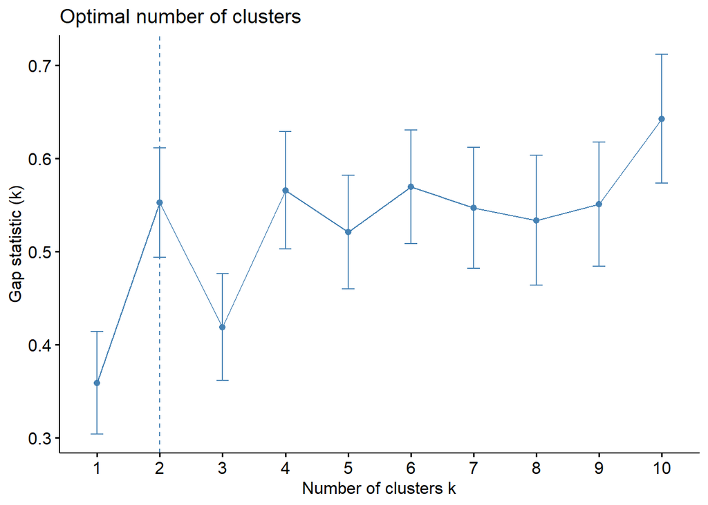

```r
set.seed(777)
row.names(Datacovidof)=Datacovidof$Pais
Datacovidof=na.omit(Datacovidof)
g.distsalud = daisy(Datacovidof[,c(7:11)], metric='gower')
fviz_nbclust(Datacovidof[,c(7:11)], pam,diss=g.distsalud,method = 'gap_stat',k.max = 10,verbose = F)
```

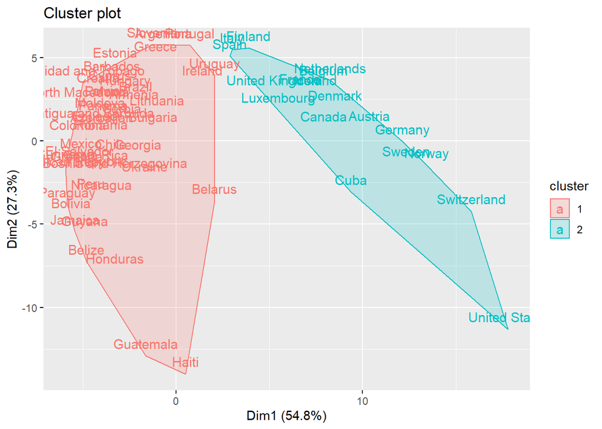

```r
res.pamSALUD=pam(g.distsalud,2,cluster.only = F)
Datacovidof$clusterPAM=res.pamSALUD$cluster
fviz_cluster(object = list(data=g.distsalud, cluster = Datacovidof$clusterPAM),
             geom = c('text'),
             ellipse.type = 'convex')
```

```r
Datacovidof[Datacovidof$clusterPAM==1,'Pais']
```

```
##  [1] "Antigua and Barbuda"    "Argentina"              "Armenia"
##  [4] "Azerbaijan"             "Barbados"               "Belarus"
##  [7] "Belize"                 "Bolivia"                "Bosnia and Herzegovina"
## [10] "Brazil"                 "Bulgaria"               "Chile"
## [13] "Colombia"               "Costa Rica"             "Croatia"
## [16] "Cyprus"                 "Dominican Republic"     "Ecuador"
## [19] "El Salvador"            "Estonia"                "Georgia"
## [22] "Greece"                 "Grenada"                "Guatemala"
## [25] "Guyana"                 "Haiti"                  "Honduras"
## [28] "Hungary"                "Ireland"                "Jamaica"
## [31] "Latvia"                 "Lithuania"              "Mexico"
## [34] "Moldova"                "Nicaragua"              "North Macedonia"
## [37] "Panama"                 "Paraguay"               "Peru"
## [40] "Poland"                 "Portugal"               "Romania"
## [43] "Serbia"                 "Slovenia"               "Suriname"
## [46] "Trinidad and Tobago"    "Turkey"                 "Ukraine"
## [49] "Uruguay"
```

```r
Datacovidof[Datacovidof$clusterPAM==2,'Pais']
```

```
##  [1] "Austria"        "Belgium"        "Canada"         "Cuba"
##  [5] "Denmark"        "Finland"        "France"         "Germany"
##  [9] "Iceland"        "Italy"          "Luxembourg"     "Netherlands"
## [13] "Norway"         "Spain"          "Sweden"         "Switzerland"
## [17] "United Kingdom" "United States"
```

#Jerarquización

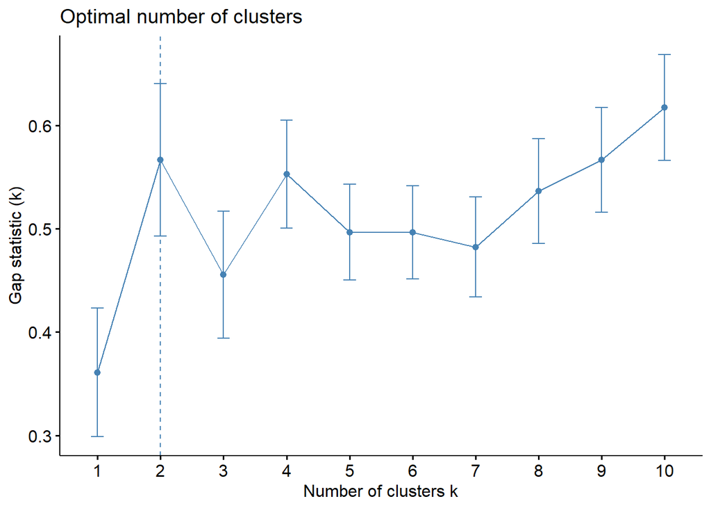

```r
fviz_nbclust(Datacovidof[,c(4,7:11)], hcut,diss=g.distsalud,method = 'gap_stat',k.max = 10,verbose = F)
```

#Aglomerativo - Agnes

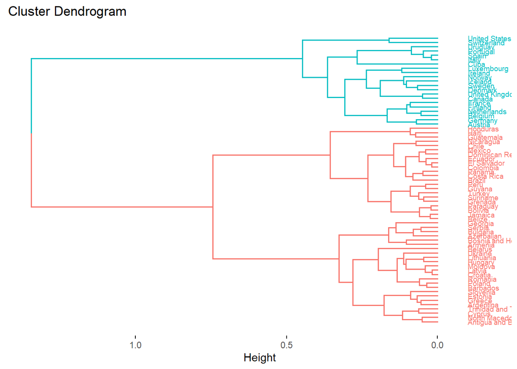

```r
res.agSALUD = hcut(g.distsalud, k = 2,hc_func='agnes',hc_method = 'ward.D')
Datacovidof$clusterAG=res.agSALUD$cluster
fviz_dend(res.agSALUD,k=2, cex = 0.5, horiz = T)
```

```r
Datacovidof[Datacovidof$clusterAG==1,'Pais']
```

```
##  [1] "Antigua and Barbuda"    "Argentina"              "Armenia"
##  [4] "Azerbaijan"             "Barbados"               "Belarus"
##  [7] "Belize"                 "Bolivia"                "Bosnia and Herzegovina"
## [10] "Brazil"                 "Bulgaria"               "Chile"
## [13] "Colombia"               "Costa Rica"             "Croatia"
## [16] "Cyprus"                 "Dominican Republic"     "Ecuador"
## [19] "El Salvador"            "Estonia"                "Georgia"
## [22] "Greece"                 "Grenada"                "Guatemala"
## [25] "Guyana"                 "Haiti"                  "Honduras"
## [28] "Hungary"                "Jamaica"                "Latvia"
## [31] "Lithuania"              "Mexico"                 "Moldova"
## [34] "Nicaragua"              "North Macedonia"        "Panama"
## [37] "Paraguay"               "Peru"                   "Poland"
## [40] "Romania"                "Serbia"                 "Slovenia"
## [43] "Suriname"               "Trinidad and Tobago"    "Turkey"
## [46] "Ukraine"
```

```r
Datacovidof[Datacovidof$clusterAG==2,'Pais']
```

```
##  [1] "Austria"        "Belgium"        "Canada"         "Cuba"
##  [5] "Denmark"        "Finland"        "France"         "Germany"
##  [9] "Iceland"        "Ireland"        "Italy"          "Luxembourg"
## [13] "Netherlands"    "Norway"         "Portugal"       "Spain"
## [17] "Sweden"         "Switzerland"    "United Kingdom" "United States"
## [21] "Uruguay"
```

# Divisivo - Diana

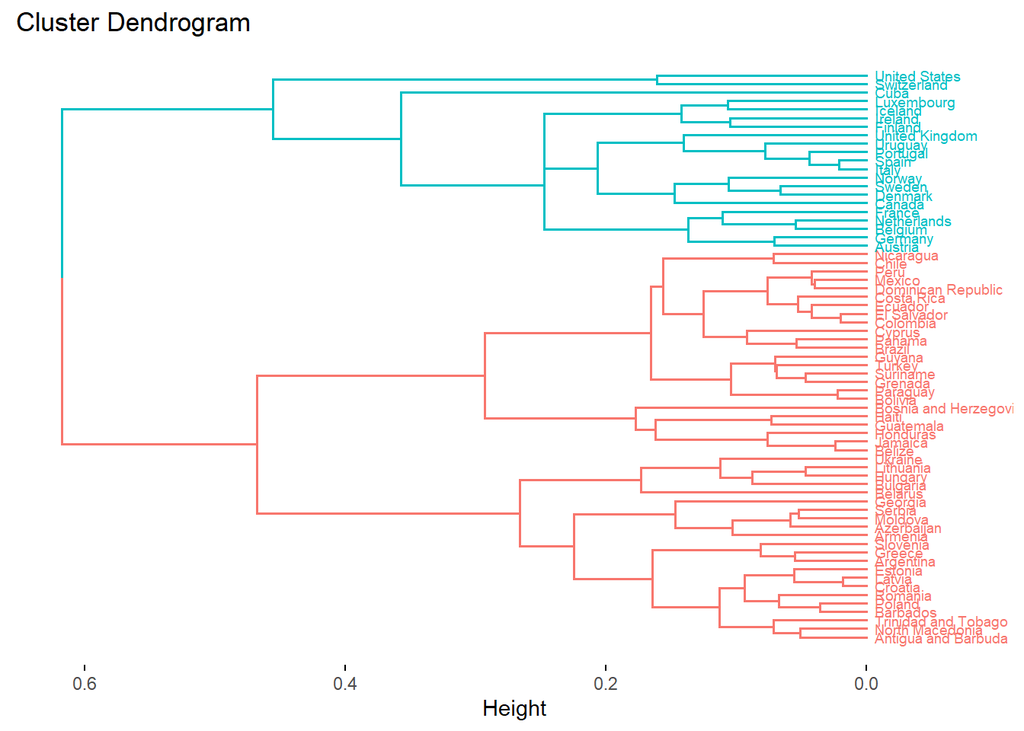

```r
res.diaSALUD = hcut(g.distsalud, k = 2,hc_func='diana')
Datacovidof$clusterDIV=res.diaSALUD$cluster
fviz_dend(res.diaSALUD, cex = 0.5,horiz = T)
```

```r
Datacovidof[Datacovidof$clusterDIV==1,'Pais']
```

```
##  [1] "Antigua and Barbuda"    "Argentina"              "Armenia"
##  [4] "Azerbaijan"             "Barbados"               "Belarus"
##  [7] "Belize"                 "Bolivia"                "Bosnia and Herzegovina"
## [10] "Brazil"                 "Bulgaria"               "Chile"
## [13] "Colombia"               "Costa Rica"             "Croatia"
## [16] "Cyprus"                 "Dominican Republic"     "Ecuador"
## [19] "El Salvador"            "Estonia"                "Georgia"
## [22] "Greece"                 "Grenada"                "Guatemala"
## [25] "Guyana"                 "Haiti"                  "Honduras"
## [28] "Hungary"                "Jamaica"                "Latvia"
## [31] "Lithuania"              "Mexico"                 "Moldova"
## [34] "Nicaragua"              "North Macedonia"        "Panama"
## [37] "Paraguay"               "Peru"                   "Poland"
## [40] "Romania"                "Serbia"                 "Slovenia"
## [43] "Suriname"               "Trinidad and Tobago"    "Turkey"
## [46] "Ukraine"
```

```r
Datacovidof[Datacovidof$clusterDIV==2,'Pais']
```

```
##  [1] "Austria"        "Belgium"        "Canada"         "Cuba"
##  [5] "Denmark"        "Finland"        "France"         "Germany"
##  [9] "Iceland"        "Ireland"        "Italy"          "Luxembourg"
## [13] "Netherlands"    "Norway"         "Portugal"       "Spain"
## [17] "Sweden"         "Switzerland"    "United Kingdom" "United States"
## [21] "Uruguay"
```

#Evaluación gráfica con siluetas

```
##   cluster size ave.sil.width
## 1       1   49          0.44
## 2       2   18          0.40
```

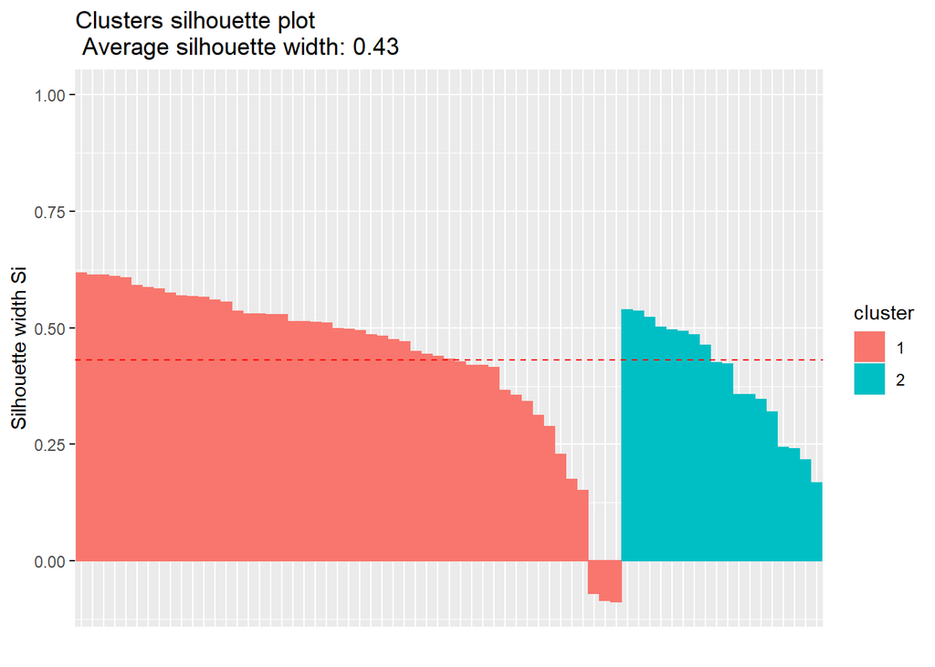

```r
fviz_silhouette(res.pamSALUD)
```

```
##   cluster size ave.sil.width
## 1       1   46          0.46
## 2       2   21          0.37
```

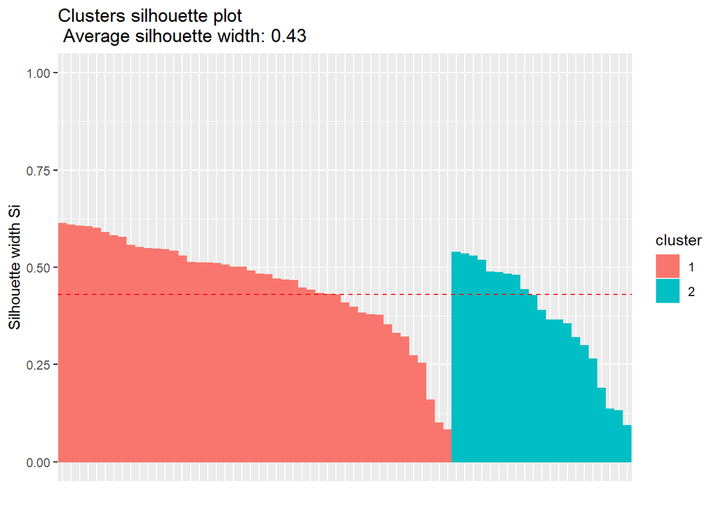

```r
fviz_silhouette(res.agSALUD)
```

```
##   cluster size ave.sil.width
## 1       1   46          0.46
## 2       2   21          0.37
```

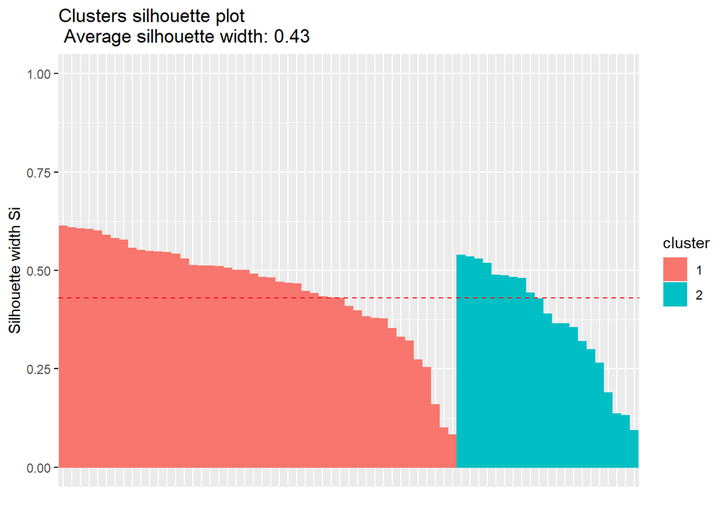

```r
fviz_silhouette(res.diaSALUD)
```

#Evaluación numérica

```r
poorPAMSALUD=data.frame(res.pamSALUD$silinfo$widths)
poorPAMSALUD$Pais=row.names(poorPAMSALUD)
poorPAMcasesSALUD=poorPAMSALUD[poorPAMSALUD$sil_width<0,'Pais']
poorPAMcasesSALUD
```

```
## [1] "Ireland"  "Uruguay"  "Portugal"
```

```r
length(poorPAMcasesSALUD)
```

```
## [1] 3
```

```r
poorAGNESSALUD=data.frame(res.agSALUD$silinfo$widths)
poorAGNESSALUD$Pais=row.names(poorAGNESSALUD)
poorAGNEScasesSALUD=poorAGNESSALUD[poorAGNESSALUD$sil_width<0,'Pais']
poorAGNEScasesSALUD
```

```
## character(0)
```

```r
length(poorAGNEScasesSALUD)
```

```
## [1] 0
```

```r
poorDIANASALUD=data.frame(res.diaSALUD$silinfo$widths)
poorDIANASALUD$Pais=row.names(poorDIANASALUD)
poorDIANAcasesSALUD=poorDIANASALUD[poorDIANASALUD$sil_width<0,'Pais']
poorDIANAcasesSALUD
```

```
## character(0)
```

```r
length(poorDIANAcasesSALUD)
```

```
## [1] 0
```

#Estrategia basada en densiadad

```r
proyeccionSALUD = cmdscale(g.distsalud, k=2,add = T)
Datacovidof$dim1 = proyeccionSALUD$points[,1]
Datacovidof$dim2 = proyeccionSALUD$points[,2]
min(Datacovidof[,c('dim1','dim2')]); max(Datacovidof[,c('dim1','dim2')])
```

```
## [1] -0.4521162
```

```
## [1] 0.3723024
```

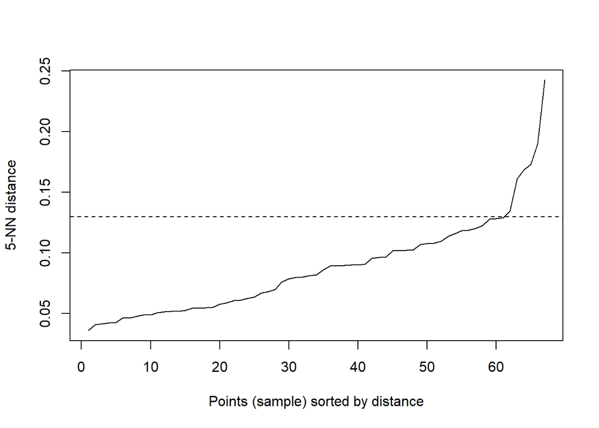

```r
limites=c(-0.5,0.4)
g.dist.cmdSALUD = daisy(Datacovidof[,c('dim1','dim2')], metric = 'euclidean')
kNNdistplot(g.dist.cmdSALUD, k=5)
abline(h=0.13, lty=2)
```

```r
db.cmdSALUD = dbscan(g.dist.cmdSALUD, eps=0.13, MinPts=5,method = 'dist')
db.cmdSALUD
```

```
## dbscan Pts=67 MinPts=5 eps=0.13
##         1
## border  3
## seed   64
## total  67
```

# CLUSTERS DE GOBERNANZA - Ivonne Mondoñedo

```r
library(cluster)
library(factoextra)
set.seed(777)
row.names(Datacovidof)=Datacovidof$Pais
Datacovidof=na.omit(Datacovidof)
g.dist_gob= daisy(Datacovidof[,c(12,17)], metric="gower")
```

#Cluster no jerarquico - Partición

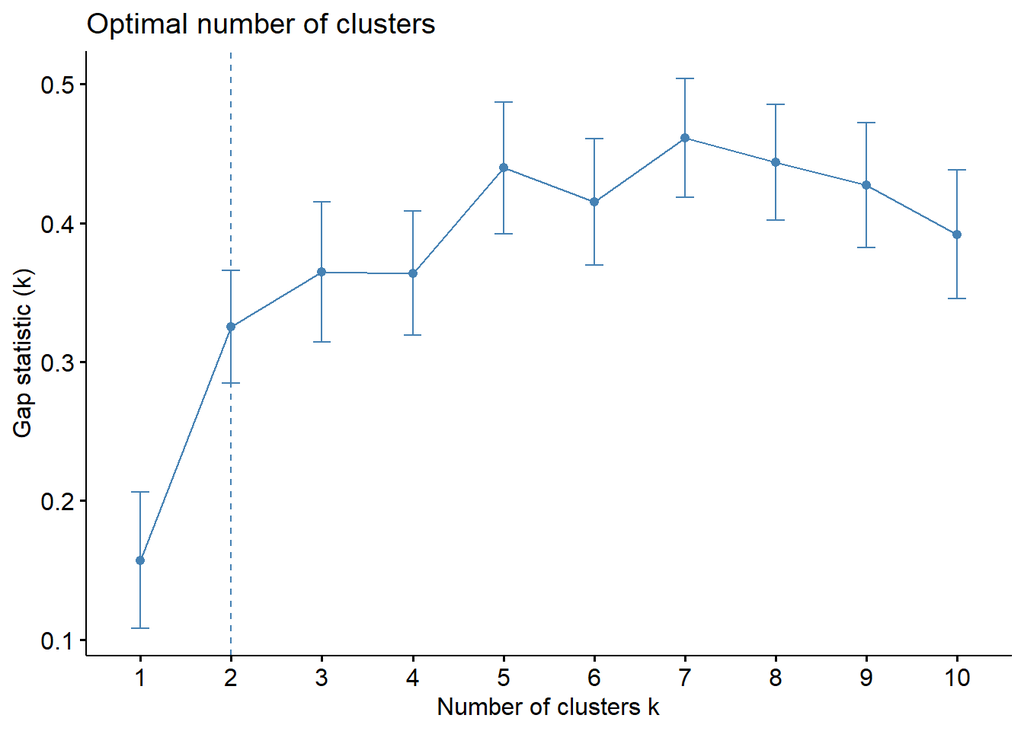

```r
fviz_nbclust(Datacovidof[,c(12,17)], pam,diss=g.dist_gob,method = "gap_stat",k.max = 10,verbose = F)
```

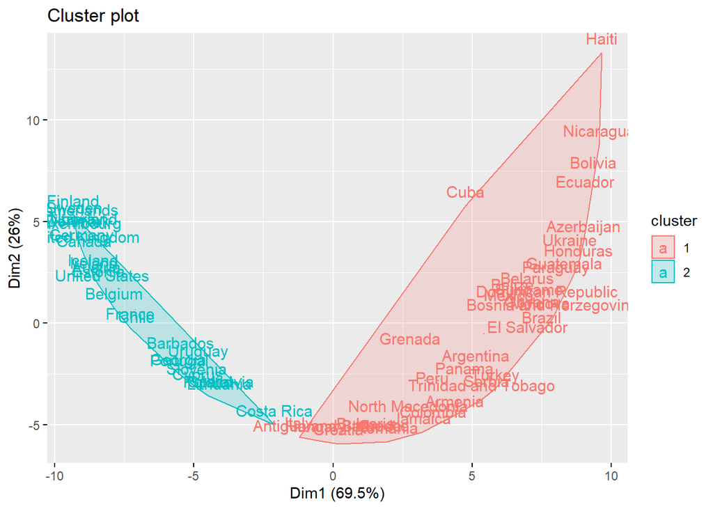

```r
res.pam_gob=pam(g.dist_gob,2,cluster.only = F)

Datacovidof$clusterPT=res.pam_gob$cluster
fviz_cluster(object = list(data=g.dist_gob, cluster = Datacovidof$clusterPT),
             geom = c("text"),
             ellipse.type = "convex")
```

```r
Datacovidof[Datacovidof$clusterPT==1,'Pais']
```

```
##  [1] "Antigua and Barbuda"    "Argentina"              "Armenia"
##  [4] "Azerbaijan"             "Belarus"                "Belize"
##  [7] "Bolivia"                "Bosnia and Herzegovina" "Brazil"
## [10] "Bulgaria"               "Colombia"               "Croatia"
## [13] "Cuba"                   "Dominican Republic"     "Ecuador"
## [16] "El Salvador"            "Greece"                 "Grenada"
## [19] "Guatemala"              "Guyana"                 "Haiti"
## [22] "Honduras"               "Hungary"                "Italy"
## [25] "Jamaica"                "Mexico"                 "Moldova"
## [28] "Nicaragua"              "North Macedonia"        "Panama"
## [31] "Paraguay"               "Peru"                   "Romania"
## [34] "Serbia"                 "Suriname"               "Trinidad and Tobago"
## [37] "Turkey"                 "Ukraine"
```

```r
Datacovidof[Datacovidof$clusterPT==2,'Pais']
```

```
##  [1] "Austria"        "Barbados"       "Belgium"        "Canada"
##  [5] "Chile"          "Costa Rica"     "Cyprus"         "Denmark"
##  [9] "Estonia"        "Finland"        "France"         "Georgia"
## [13] "Germany"        "Iceland"        "Ireland"        "Latvia"
## [17] "Lithuania"      "Luxembourg"     "Netherlands"    "Norway"
## [21] "Poland"         "Portugal"       "Slovenia"       "Spain"
## [25] "Sweden"         "Switzerland"    "United Kingdom" "United States"
## [29] "Uruguay"
```

#Clusters jerarquicos

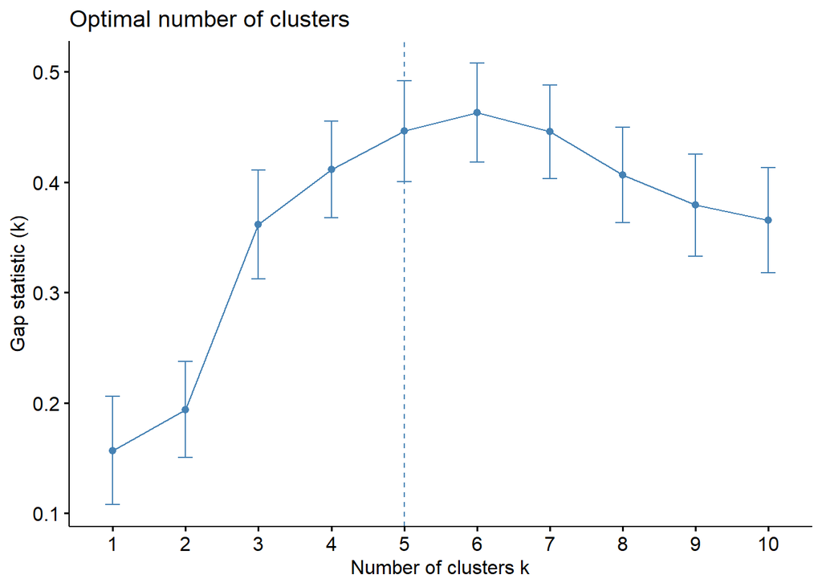

```r
fviz_nbclust(Datacovidof[,c(12,17)], hcut,diss=g.dist_gob,method = "gap_stat",k.max = 10,verbose = F)
```

#Aglomerativo - Agnes

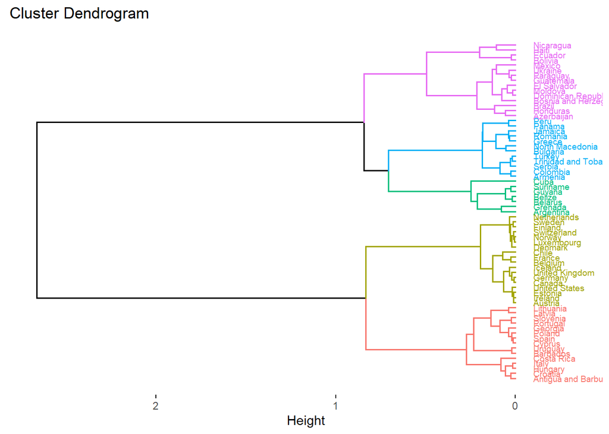

```r
res.agnes_gob = hcut(g.dist_gob, k = 5,hc_func='agnes',hc_method = "ward.D")
Datacovidof$clustAG=res.agnes_gob$cluster
fviz_dend(res.agnes_gob,k=5, cex = 0.5, horiz = T)
```

```r
Datacovidof[Datacovidof$clustAG==1,'Pais']
```

```
##  [1] "Antigua and Barbuda" "Barbados"            "Costa Rica"
##  [4] "Croatia"             "Cyprus"              "Georgia"
##  [7] "Hungary"             "Italy"               "Latvia"
## [10] "Lithuania"           "Poland"              "Portugal"
## [13] "Slovenia"            "Spain"               "Uruguay"
```

```r
Datacovidof[Datacovidof$clustAG==2,'Pais']
```

```
## [1] "Argentina" "Belarus"   "Belize"    "Cuba"      "Grenada"   "Guyana"
## [7] "Suriname"
```

```r
Datacovidof[Datacovidof$clustAG==3,'Pais']
```

```
##  [1] "Armenia"             "Bulgaria"            "Colombia"
##  [4] "Greece"              "Jamaica"             "North Macedonia"
##  [7] "Panama"              "Peru"                "Romania"
## [10] "Serbia"              "Trinidad and Tobago" "Turkey"
```

```r
Datacovidof[Datacovidof$clustAG==4,'Pais']
```

```
##  [1] "Austria"        "Belgium"        "Canada"         "Chile"
##  [5] "Denmark"        "Estonia"        "Finland"        "France"
##  [9] "Germany"        "Iceland"        "Ireland"        "Luxembourg"
## [13] "Netherlands"    "Norway"         "Sweden"         "Switzerland"
## [17] "United Kingdom" "United States"
```

```r
Datacovidof[Datacovidof$clustAG==5,'Pais']
```

```
##  [1] "Azerbaijan"             "Bolivia"                "Bosnia and Herzegovina"
##  [4] "Brazil"                 "Dominican Republic"     "Ecuador"
##  [7] "El Salvador"            "Guatemala"              "Haiti"
## [10] "Honduras"               "Mexico"                 "Moldova"
## [13] "Nicaragua"              "Paraguay"               "Ukraine"
```

#Divisivo - Diana

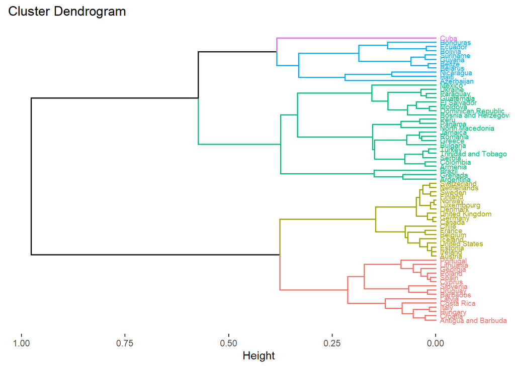

```r
res.diana_gob = hcut(g.dist_gob, k = 5,hc_func='diana')
Datacovidof$clustDIV=res.diana_gob$cluster
fviz_dend(res.diana_gob, cex = 0.5,horiz = T)
```

```r
Datacovidof[Datacovidof$clustDIV==1,'Pais']
```

```
##  [1] "Antigua and Barbuda" "Barbados"            "Costa Rica"
##  [4] "Croatia"             "Cyprus"              "Georgia"
##  [7] "Hungary"             "Italy"               "Latvia"
## [10] "Lithuania"           "Poland"              "Portugal"
## [13] "Slovenia"            "Spain"               "Uruguay"
```

```r
Datacovidof[Datacovidof$clustDIV==2,'Pais']
```

```
##  [1] "Argentina"              "Armenia"                "Bosnia and Herzegovina"
##  [4] "Brazil"                 "Bulgaria"               "Colombia"
##  [7] "Dominican Republic"     "El Salvador"            "Greece"
## [10] "Grenada"                "Guatemala"              "Jamaica"
## [13] "Mexico"                 "Moldova"                "North Macedonia"
## [16] "Panama"                 "Paraguay"               "Peru"
## [19] "Romania"                "Serbia"                 "Trinidad and Tobago"
## [22] "Turkey"                 "Ukraine"
```

```r
Datacovidof[Datacovidof$clustDIV==3,'Pais']
```

```
##  [1] "Austria"        "Belgium"        "Canada"         "Chile"
##  [5] "Denmark"        "Estonia"        "Finland"        "France"
##  [9] "Germany"        "Iceland"        "Ireland"        "Luxembourg"
## [13] "Netherlands"    "Norway"         "Sweden"         "Switzerland"
## [17] "United Kingdom" "United States"
```

```r
Datacovidof[Datacovidof$clustDIV==4,'Pais']
```

```
##  [1] "Azerbaijan" "Belarus"    "Belize"     "Bolivia"    "Ecuador"
##  [6] "Guyana"     "Haiti"      "Honduras"   "Nicaragua"  "Suriname"
```

```r
Datacovidof[Datacovidof$clustDIV==5,'Pais']
```

```
## [1] "Cuba"
```

#Evaluación gráfica con siluetas

```
##   cluster size ave.sil.width
## 1       1   38          0.48
## 2       2   29          0.73
```

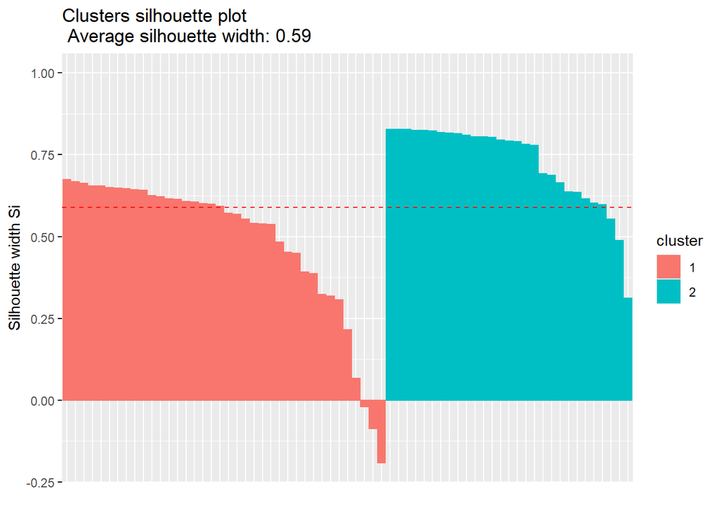

```r
fviz_silhouette(res.pam_gob)
```

```
##   cluster size ave.sil.width
## 1       1   15          0.36
## 2       2    7          0.49
## 3       3   12          0.54
## 4       4   18          0.72
## 5       5   15          0.27
```

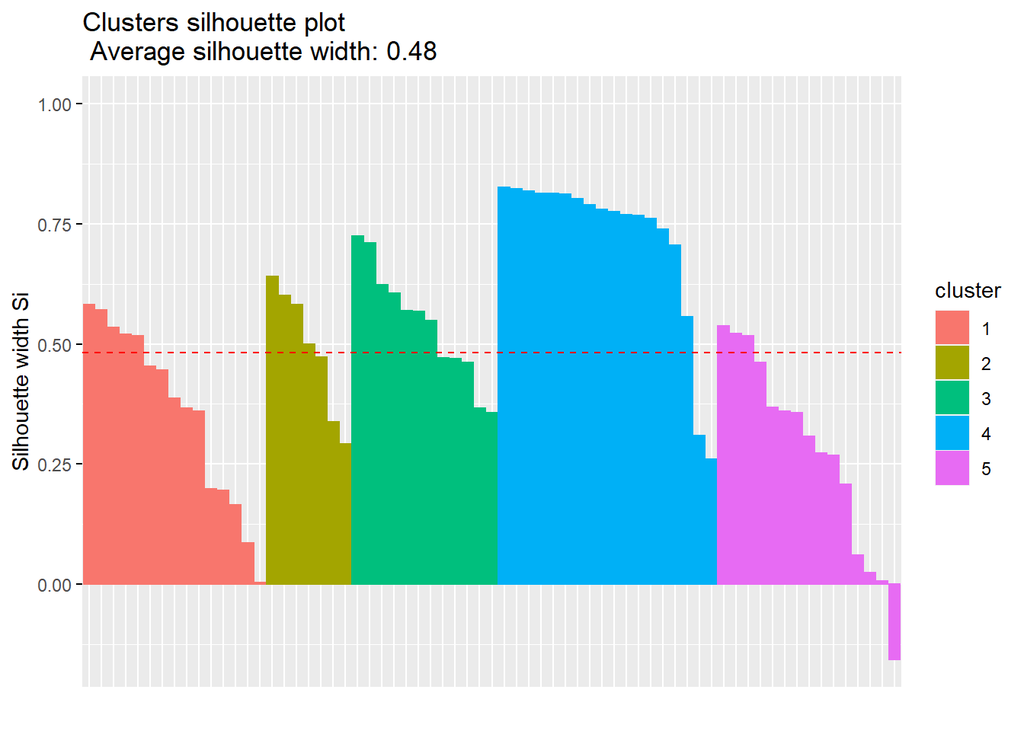

```r
fviz_silhouette(res.agnes_gob)
```

```
##   cluster size ave.sil.width
## 1       1   15          0.45
## 2       2   23          0.25
## 3       3   18          0.72
## 4       4   10          0.25
## 5       5    1          0.00
```

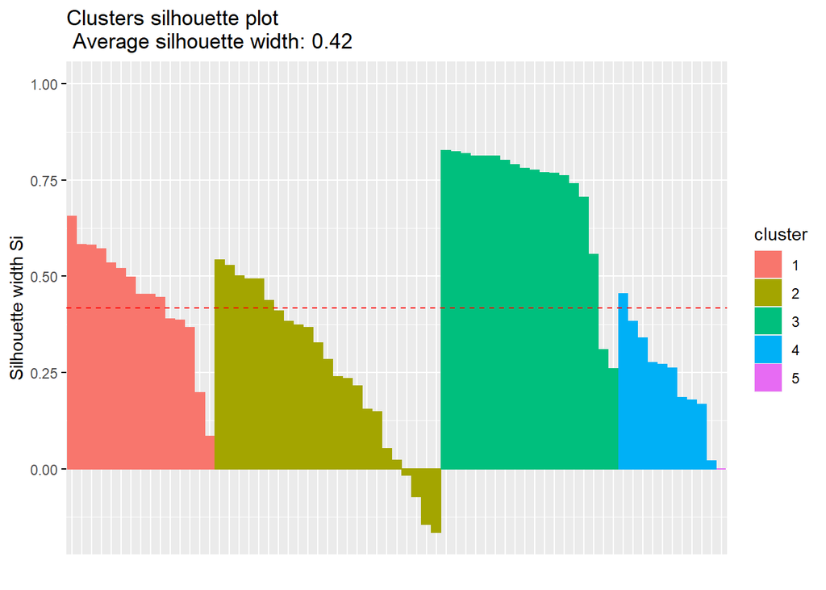

```r
fviz_silhouette(res.diana_gob)
```

#Evaluacion númerica

```r
poorPAM_Gob=data.frame(res.pam_gob$silinfo$widths)
poorPAM_Gob$Pais=row.names(poorPAM_Gob)

poorPAMcases_gob=poorPAM_Gob[poorPAM_Gob$sil_width<0,'Pais']
# osea:
poorPAMcases_gob
```

```
## [1] "Antigua and Barbuda" "Hungary"             "Italy"
```

```r
# agnes
poorAGNES_gob=data.frame(res.agnes_gob$silinfo$widths)
poorAGNES_gob$Pais=row.names(poorAGNES_gob)
poorAGNEScases_gob=poorAGNES_gob[poorAGNES_gob$sil_width<0,'Pais']
poorAGNEScases_gob
```

```
## [1] "Brazil"
```

```r
#diana:
poorDIANA_gob=data.frame(res.diana_gob$silinfo$widths)
poorDIANA_gob$Pais=row.names(poorDIANA_gob)
poorDIANAcases_gob=poorDIANA_gob[poorDIANA_gob$sil_width<0,'Pais']
poorDIANAcases_gob
```

```
## [1] "Romania"  "Greece"   "Grenada"  "Bulgaria"
```

#Estrategia basada en densidad

```r
proyeccion_gob= cmdscale(g.dist_gob, k=2,add = T)
Datacovidof$dim1 <- proyeccion_gob$points[,1]
Datacovidof$dim2 <- proyeccion_gob$points[,2]
```

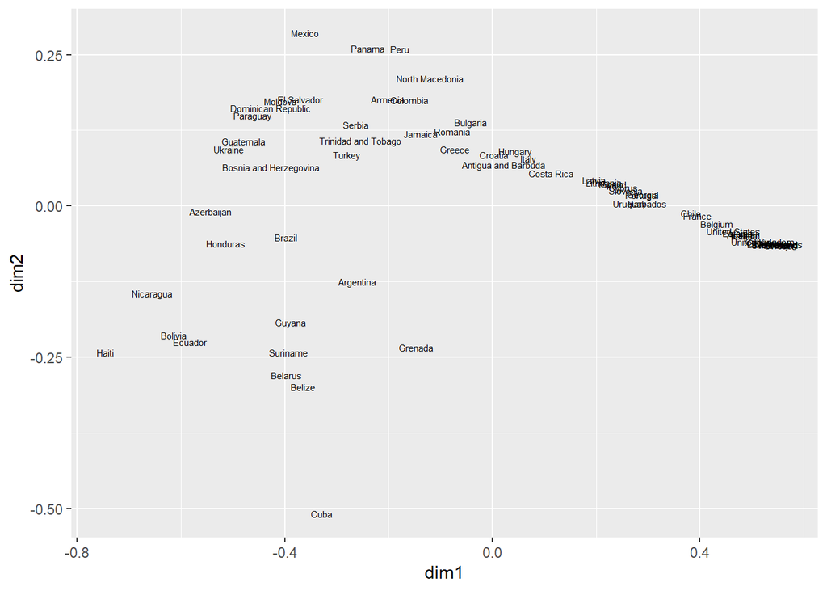

```r
base_gob= ggplot(Datacovidof,aes(x=dim1, y=dim2,label=row.names(Datacovidof)))
base_gob + geom_text(size=2)
```

```r
Datacovidof$pam=as.factor(res.pam_gob$clustering)
Datacovidof$agnes=as.factor(res.agnes_gob$cluster)
Datacovidof$diana=as.factor(res.diana_gob$cluster)
```

```r
min(Datacovidof[,c('dim1','dim2')]); max(Datacovidof[,c('dim1','dim2')])
```

```
## [1] -0.7459546
```

```
## [1] 0.5616711
```

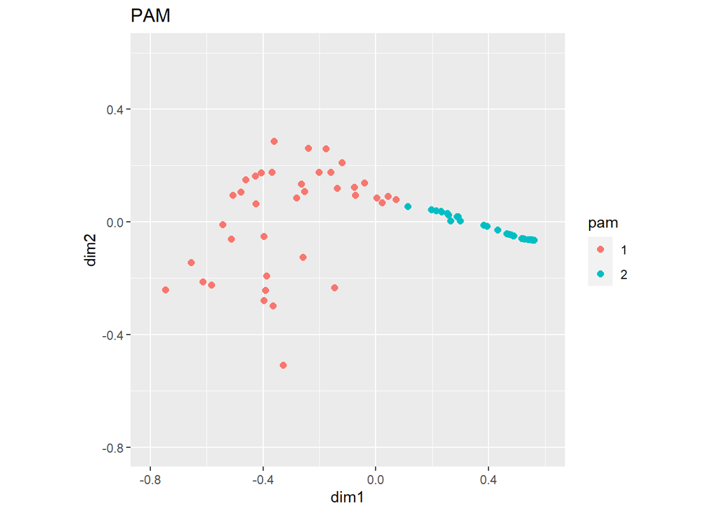

```r
limites=c(-0.8,0.6)

base_gob= ggplot(Datacovidof,aes(x=dim1, y=dim2)) + ylim(limites) + xlim(limites) + coord_fixed()
base_gob + geom_point(size=2, aes(color=pam))  + labs(title = "PAM")
```

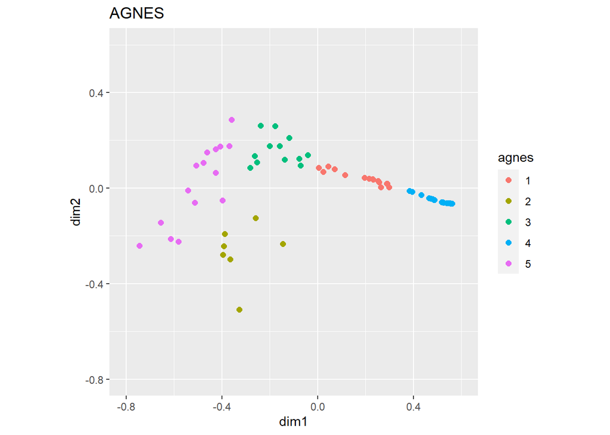

```r
base_gob + geom_point(size=2, aes(color=agnes)) + labs(title = "AGNES")
```

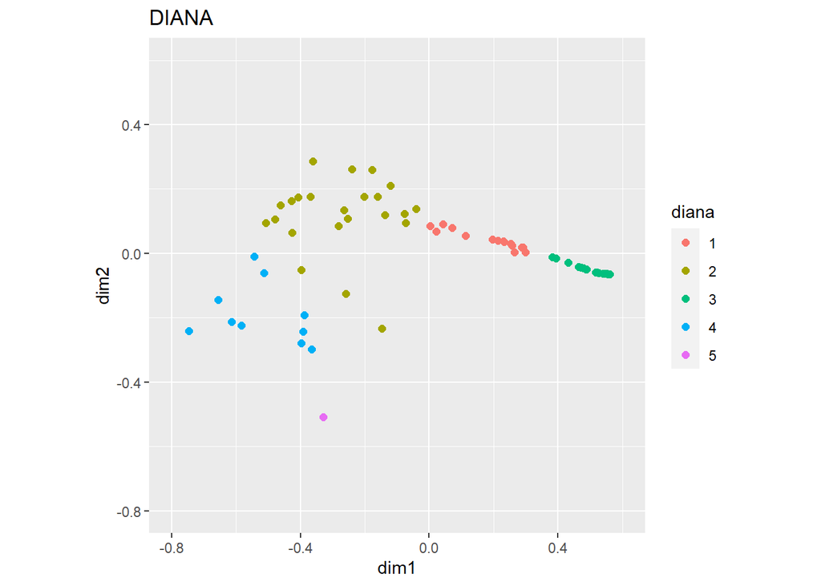

```r
base_gob + geom_point(size=2, aes(color=diana)) + labs(title = "DIANA")
```

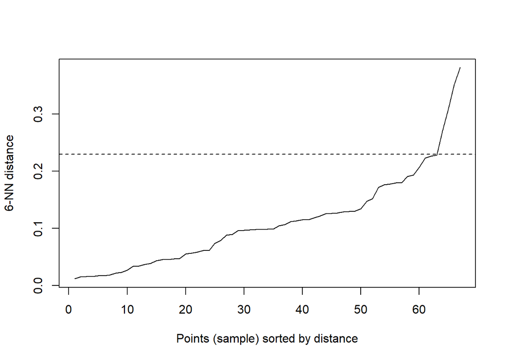

```r
library(dbscan)
library(cluster)

g.dist.cmd_gob=daisy(Datacovidof[,c('dim1','dim2')], metric = 'euclidean')
kNNdistplot(g.dist.cmd_gob, k=6)
abline(h=0.23, lty=2)
```

```r
library(fpc)
db.cmd_gob= dbscan(g.dist.cmd_gob, eps=0.23, MinPts=6,method = 'dist')
db.cmd_gob
```

```
## dbscan Pts=67 MinPts=6 eps=0.23
##         1
## border  3
## seed   64
## total  67
```

```r
Datacovidof$dbCMD_gob=as.factor(db.cmd_gob$cluster)
```

```r
library(ggrepel)
```

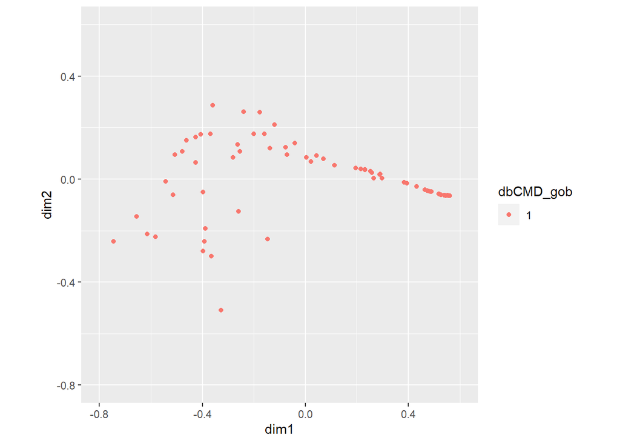

```r
base_gob= ggplot(Datacovidof,aes(x=dim1, y=dim2)) + ylim(limites) + xlim(limites) + coord_fixed()
dbplot_gob= base_gob + geom_point(aes(color=dbCMD_gob))
dbplot_gob
```

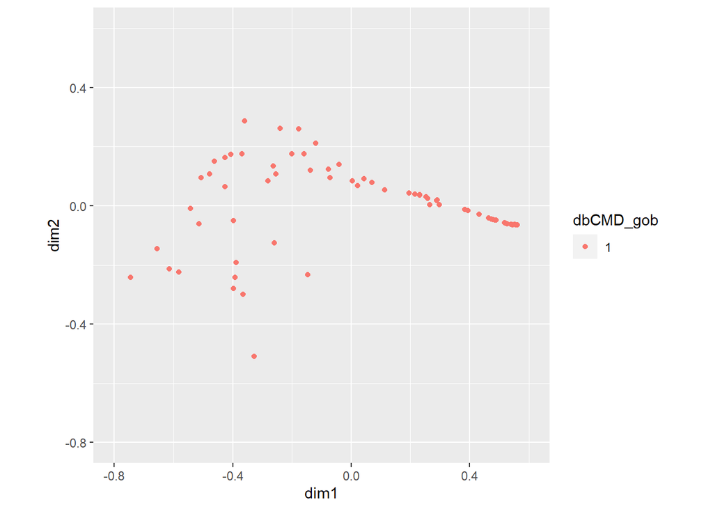

```r
LABEL=ifelse(Datacovidof$dbCMD_gob==0,row.names(Merge_Gobernanza),"")
dbplot_gob + geom_text_repel(aes(label=LABEL),
                         size=6,
                         direction = "y", ylim = 0.45,
                         angle=45,
                         segment.colour = "grey")
```

# Clusters de agua potable y saneamiento (Mayra Vargas)

```r
library(cluster)
library(factoextra)
library(stringr)
library(magrittr)
set.seed(777)
row.names(Datacovidof)=Datacovidof$Pais
Datacovidof=na.omit(Datacovidof)
distancia= daisy(Datacovidof[,c(5,6)],metric = "gower")
```

#Cluster no jerárquico - partición

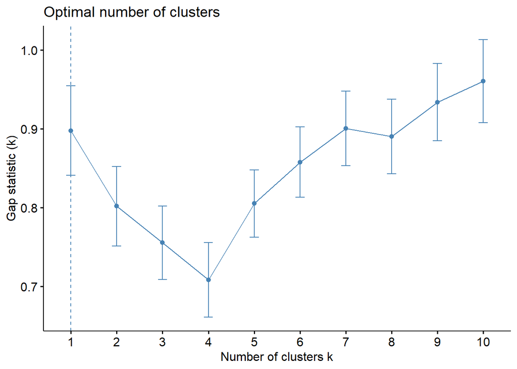

```r
fviz_nbclust(Datacovidof[,c(5,6)], pam, diss = distancia,method = "gap_stat",k.max = 10,verbose = F)
```

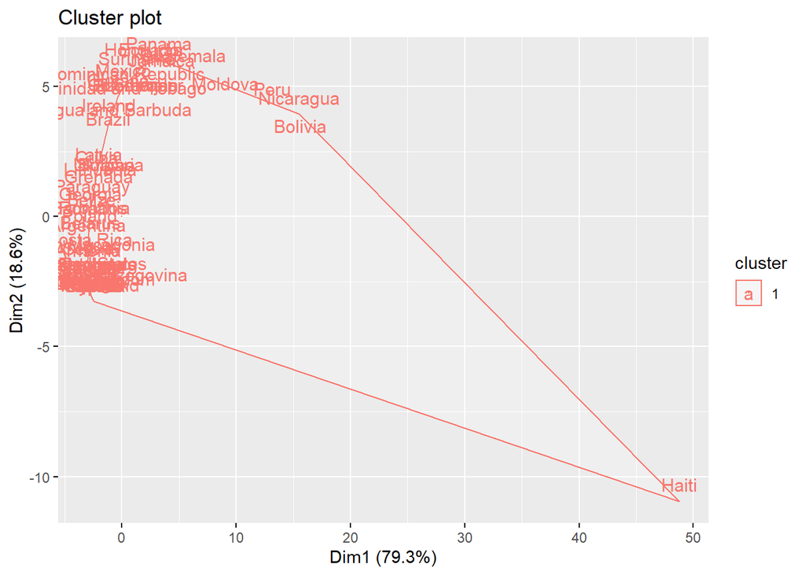

```r
pam.resultado = pam(distancia,1,cluster.only = F)
Datacovidof$clusterAS=pam.resultado$cluster
fviz_cluster(object = list(data=distancia, cluster = Datacovidof$clusterAS),
             geom = c("text"),
             ellipse.type = "convex")
```

#Clusters jerarquicos

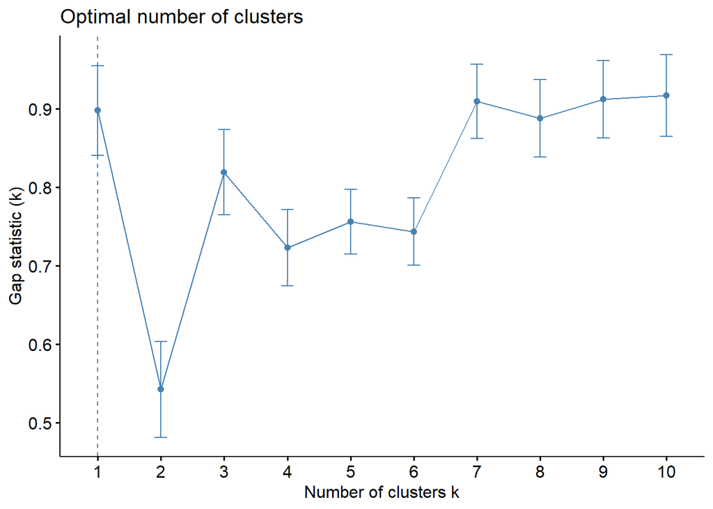

```r
fviz_nbclust(Datacovidof[,c(5,6)], hcut, diss = distancia,method = "gap_stat",k.max = 10,verbose = F)
```

#Aglomerativo - Agnes

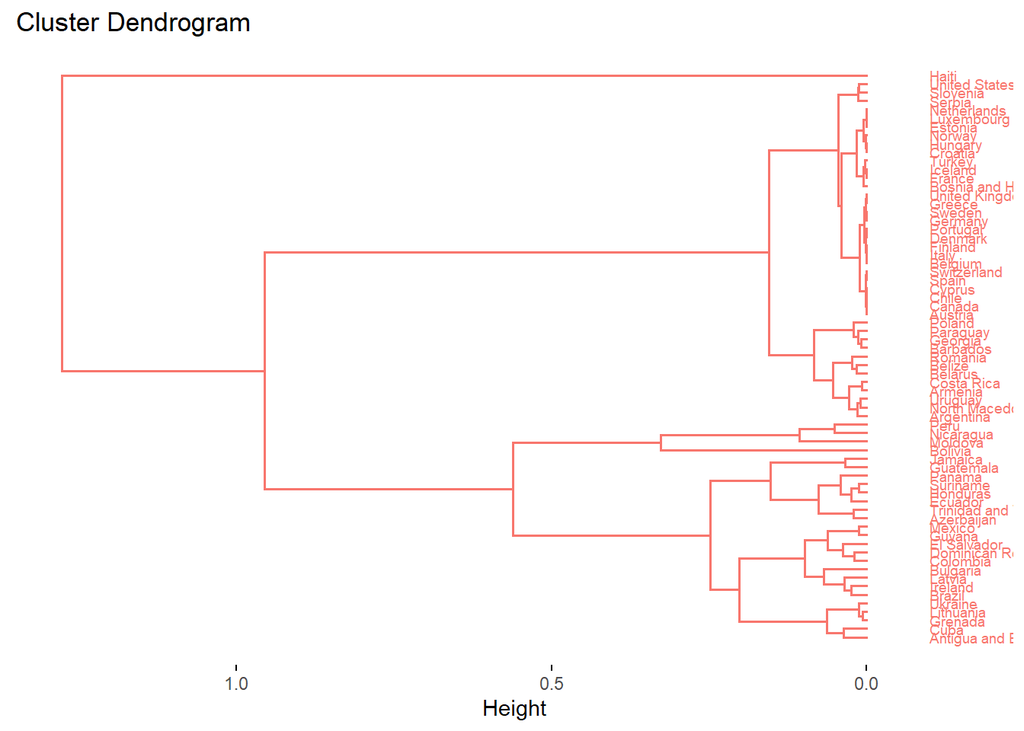

```r
res.agnes<-hcut(distancia, k = 1,hc_func='agnes',hc_method = "ward.D")
Datacovidof$clusterAgnes=res.agnes$cluster
fviz_dend(res.agnes,k=1, cex = 0.5, horiz = T)
```

#Divisivo - Diana

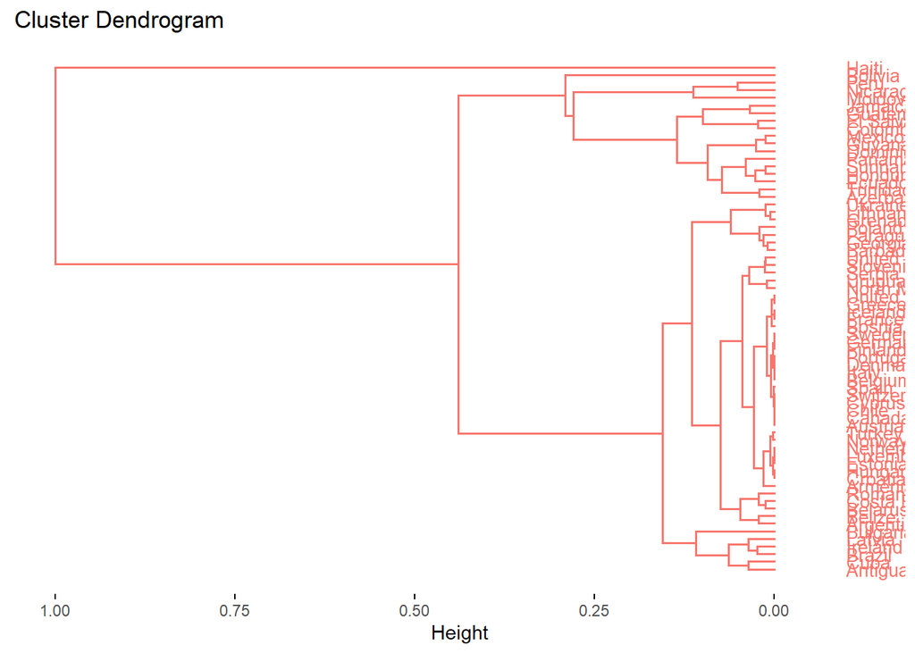

```r
res.diana <- hcut(distancia, k = 1,hc_func='diana')
Datacovidof$clusterDivisivo=res.diana$cluster
fviz_dend(res.diana, cex = 0.7,horiz = T)
```

#Estrategia basada en densidad

```r
proyeccionAS = cmdscale(distancia, k=2,add = T)
```